# Ecommerce Funnel & Attribution Analysis

IBM 6530 · Final Presentation

Bansi Khachar · Matthew Prado · Lucynda Young · Saurabh Parate

2026-05-06

## The Business Problem

An ecommerce platform is generating strong traffic but converting almost none of it into revenue.

Despite **2,546 distinct users** visiting on a single day, only **17 purchases** were completed.

**Overall CVR: 0.7%** — fewer than 1 in 100 visitors completes a purchase

**Why it matters**

- Revenue is being lost at every funnel stage
- Without knowing where users drop off, marketing budget cannot be allocated efficiently
- Without attribution, the business cannot identify which touchpoints drive conversions

## Project Objectives

1. **Identify and quantify** drop-off points across the purchase funnel using GA4 + BigQuery
2. **Build a stakeholder-ready dashboard** with clean mart logic and correct KPI definitions
3. **Apply attribution analysis** to determine which funnel stages most influence purchase completion
4. **Deliver actionable recommendations** to improve the 0.7% conversion rate

## Data & Methodology

**Data source**

- GA4 Obfuscated Sample
- BigQuery Public Dataset
- Single-day snapshot: Jan 31, 2021
- Accessed via `bigrquery` + `dbplyr` in R

**Tools**

- R · BigQuery · ChannelAttribution
- Quarto · Looker Studio

**Analytical components**

| Component | Purpose |
| --- | --- |
| Descriptive | KPIs + funnel rates |
| Funnel analysis | Drop-off by stage |
| Markov Chain | Attribution model |
| Heuristic models | First / last touch |

## Core KPIs

| Metric | Value |
| --- | --- |
| Total Events | 26,489 |
| Distinct Users | 2,546 |
| Purchases | **17** |
| Overall CVR | **0.7%** |

The platform generates roughly **10 events per user** per session — engagement is not the problem. Conversion is.

## Funnel Performance

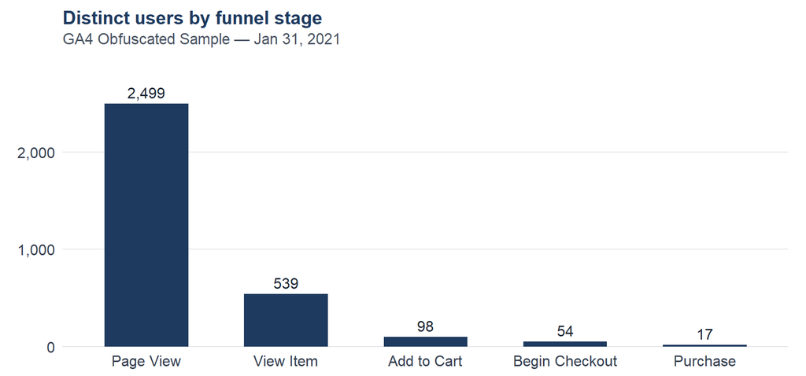

## Where Users Drop Off

| Transition | Drop-off | Priority |
| --- | --- | --- |
| page_view → view_item | 78.4% | Critical |
| view_item → add_to_cart | 81.8% | Critical |
| add_to_cart → begin_checkout | 44.9% | Moderate |
| begin_checkout → purchase | 68.5% | Critical |

**3 of 4 transitions exceed 68% drop-off.** The product page and checkout experience are the two highest-priority fixes.

## Attribution Methodology

**Setup**

- Unit: individual user session via `user_pseudo_id`
- Touchpoints: all 5 funnel events
- Package: `ChannelAttribution` in R

**Path defined as:**

`page_view` → `view_item` → `add_to_cart` → `begin_checkout` → `purchase`

**Why Markov Chain?**

| Model | Weakness |
| --- | --- |
| First-touch | Ignores all steps after entry |
| Last-touch | Over-credits the final step |
| **Markov Chain** | Accounts for full journey |

Markov uses a **removal effect** — it measures how much conversion probability drops when each stage is removed from the path.

## Attribution Results

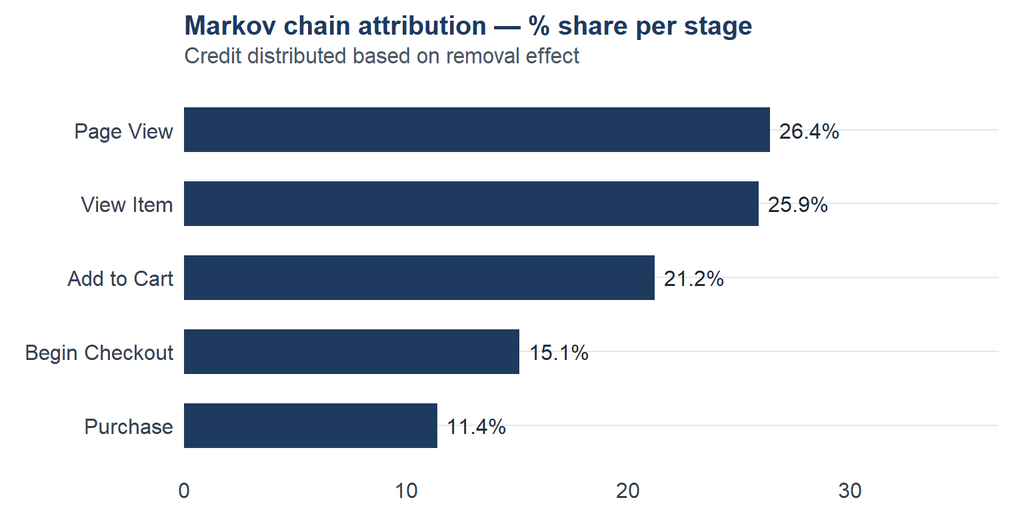

`page_view` + `view_item` together account for **52.3%** of total conversion credit.

## Attribution Model Comparison

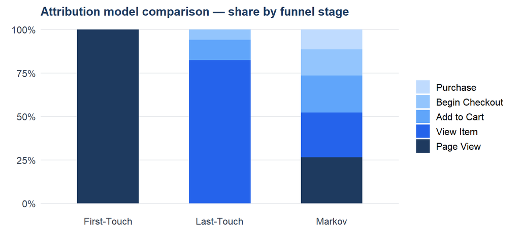

## Recommendations

**1. Fix landing page**

78.4% of users never view a product

- Featured items above the fold
- Improve search & navigation
- A/B test homepage layout

*Est. +250 users into funnel*

**2. Optimize product pages**

81.8% who view a product don’t add to cart

- Add reviews & urgency signals
- Benefit-led copy
- A/B test CTA placement

*Est. +54 add-to-cart users*

**3. Reduce checkout friction**

68.5% abandon at checkout

- Enable guest checkout
- Reduce form fields
- Trust badges + mobile UX

*CVR: 0.7% → ~1.1%*

## Next Steps

**Short term (0–30 days)**

- Implement homepage A/B test
- Add reviews to top 10 product pages
- Enable guest checkout

**Medium term (30–90 days)**

- Collect 30 days of data for reanalysis
- Implement consistent `user_id` tagging in GA4
- Connect campaign source data to sessions

**Long term (90+ days)**

- Integrate CRM + campaign data into BigQuery
- Run full Markov attribution with 100+ conversions
- Build channel-level ROI model to guide ad spend

## Summary

**What we found**

- CVR of just 0.7% from 2,546 users on a single day
- Largest drop-off: `view_item → add_to_cart` at 81.8%
- Top two funnel stages carry 52% of Markov attribution credit

**What we recommend**

1. Fix the landing-to-product discovery gap
2. Optimize the product detail page experience
3. Remove checkout friction — CVR can reach ~1.1%

**Deliverables**

- Looker Studio Dashboard
- Quarto Reproducible Report
- This Presentation

**Data**

- GA4 Obfuscated Sample via BigQuery
- Single-day snapshot: Jan 31, 2021

## Thank You

**Questions & Discussion**

Bansi Khachar · Matthew Prado · Lucynda Young · Saurabh Parate

IBM 6530 · Cal Poly Pomona

github.com/MattPradoCalPoly/project-IBM6530